# Definitions

## Approximate Integration: Euler's Method

In Euler's method of approximate integration, also called the "rectangular approximation" of an integral, The area under a curve, $y(t)$, which yields $\int y(t) dt = Y(t)$, can be *approximated* by repeatedly summing the area of rectangles projected either forwards or backwards in time from each discrete measurement of $y$. The process begins with some initial, known value of the integral $Y_0$, the value of $Y(t)$ is incremented by the area of the corresponding rectangle on the plot of $y(t)$. The process is shown visually below.

Link to Original Context in: Reading_06

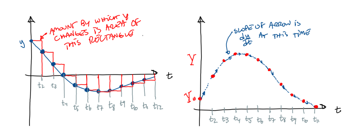

As you can see in the second plot, the idea is to use one, known value of our integral, $Y$, at the very start of the procedure. This is often called the *initial value* of $Y$. Then, the area under the derivative plot from $y(t_1)$ to $y(t_2)$ is added to our estimate of $Y$, and this value, when added to $Y_0$, becomes $Y(t_2)$. Formally, this can be written as:

$Y(t_2) = Y_0 + y(t1)\cdot(t_2-t_1)$

From $t_2$ to $t_3$, the procedure is repeated. In other words, the rectangle defined by the value of $y(t_2)$ is used to add "a little more" to our estimate to produce $Y(t_3)$. Formally,

$Y(t_3) = Y_0 + y(t_1)\cdot(t_2-t_1) + y_(t_2)\cdot(t_3-t_2)$

Using a "recursive formulation," we could equivalently write:

$Y(t_3) = Y(t_2) + y(t_2)\cdot(t_3-t_2)$

And so on. **In this description, we projected the value of $y$ forwards in the creation of our approximate rectangles. Therefore, this particular variant of Euler integration is called "Forward Euler" integration.** "Backward Euler" integration is also possible. As with approximations of derivatives, the smaller the differences between times we use in the projection of the rectangles, the better our approximation of the derivative will be.

Because approximate integration is often performed on data arranged as arrays, we can use the counting index $k$ to write this as an equation that could be built into a "for loop" and computed efficiently in code. Considering arrays representing time $t$, derivative $y$, and integral $Y$, we could write an equation for any entry in the output array $Y(k)$ as:

$Y(k) = Y(k-1) + y(k-1)\cdot(t(k)-t(k-1))$

This should look similar to the equation for a line that you might use for *linear extrapolation*. Indeed, this equation is an equation for a line in point-slope form. We use each estimate for $Y(k-1)$ to produce an estimate for the *next* value of our integral $Y(k)$ using linear extrapolation. This is shown visually on the right panel of the plot above.

An example of how to implement approximate Euler integration in MATLAB/Octave is shown below. The approximate integral is compared with the "true" integral of the function to show its accuracy. Try changing the timestep $T$ in the code cell below to see how accuracy is affected by the size of the time step used for extrapolation/integration. A large value of $T$ is problematic for the same reason large extrapolations were problematic in Reading 4.

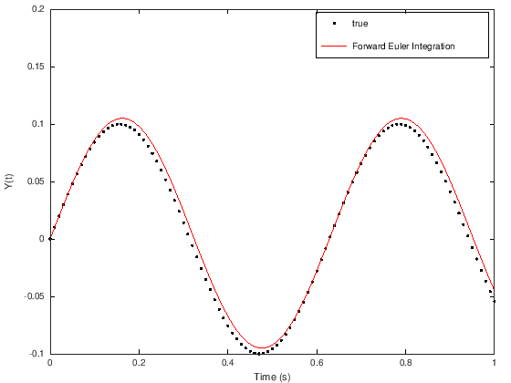

```matlab
T = 0.01; %timestep
t = 0:T:1; %time vector
y = cos(10*t); %function we wish to integrate. This may come from data rather than a known function of t.

Y_estimate = zeros(size(t)); %initialize an array to hold our estimates for Y, the integral of y.
Y0 = 0; %some initial, known value for the integral at the beginning.
Y_estimate(1) = Y0; %place this value in the first entry of our array

Y_true = 0.1*sin(10*t); %for this example, we know that d/dt(sin(t)) = cos(t).
%We will use this "exact" solution to the integral to allow us to see how accurate Euler integration is.

%now set up a for-loop starting at the second entry in Y_estimate, since we already know Y_estimate(1)=Y0
for k=2:length(t) %automatically set up the for-loop to be the right length
    %now implement Euler's formula. remember that here, y is dY/dt.
    Y_estimate(k) = Y_estimate(k-1) + y(k-1)*(t(k)-t(k-1));
end

%now we will compare our approximate integral with our "true" value to see if Euler integration works.

figure
plot(t,Y_true,'k.',t,Y_estimate,'r')
xlabel('Time (s)')
ylabel('Y(t)')
legend('true','Forward Euler Integration')
```

## Empirical Models: fitting polynomials in MATLAB/Octave

Link to Original Context in: Reading_06

MATLAB/Octave can be used to estimate a "best fit" polynomial function to match a dataset. The term "best fit," in this context, means that the sum of the squared error between the model and the data is minimized. The command used to produce the set of coefficients is "polyfit." An example of how to use the "polyfit" command to produce the best-fit line for a dataset is shown below.

```
m_estimate = -3.0104
b_estimate =  4.0666
```

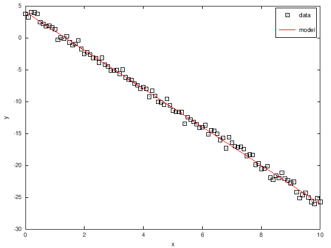

```matlab
% first, create some fake "data" we will fit a line to, in order to see how "polyfit" works.
xfakedata = 0:.1:10;
yfakedata = -3*xfakedata + 4 + .5*randn(size(xfakedata)); %the randn() on the end produces some random "noise" on our fake data.
%this simulates the effect of having error in our measurements. If polyfit does its job, we should get the line y = -3x+4 back!

%now we will actually use polyfit. The array "coefficients" will contain [m b] in the equation y = m*x+b.
%the second argument to the polyfit() function is the ORDER of the polynomial. A line is a polynomial of order 1.
%for reference, a quadratic is a polynomial of order 2.
coefficients = polyfit(xfakedata,yfakedata,1);
%was m=-3 and b=4?
m_estimate = coefficients(1)
b_estimate = coefficients(2)

%now, these coefficients fully define a "model" of our relationship y = m*x+b. Let's produce predictions based on this model
ymodel = m_estimate*xfakedata + b_estimate;

%now plot the data and the model together to evaluate.
figure
plot(xfakedata,yfakedata,'ks',xfakedata,ymodel,'r')
xlabel('x')
ylabel('y')
legend('data','model')
```

## Torque or Moment

Link to Original Context in: Reading_07

A torque (also called a 'moment') is applied to an object any time a force is applied at some distance from a reference point.

If the distance from the reference point to the application point of the force is defined by a position vector $\vec{r}$, as shown below:

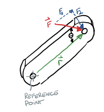

Then the magnitude of the torque applied with respect to the reference point is the product of the position vector's magnitude and the component of the force vector that is *perpendicular* to the position vector:

$$T = r\cdot F_\perp$$

Think about the picture above and imagine that you squeezed the object shown with your thumb and forefinger at the reference point. If the force $\vec{F}$ was pointed directly perpendicular to the position vector $\vec{r}$, it would be hard to keep the object from rotating... and harder yet if the position vector got larger! But if the force vector was pointed either directly towards or directly away from your grip, the object would not "want" to rotate at all! This is the intuitive definition of the mathematical equation above, relating $F_\perp$ and $r$.

The definition of the component $F_\perp$ depends on the specific geometry of a particular problem, but if the angle $\theta$ is defined as in the figure above, then we can compute that $F_\perp=F\sin\theta$, where $F$ is the magnitude of the force vector $\vec{F}$.

The *direction* of the torque is said to be perpendicular to the plane defined by the position and force vectors. Specifically, its direction can be surmised using the "right hand rule," in which one curls the fingers of the right hand from the position vector into the direction of the applied force. The direction of the torque is shown by the direction in which the thumb points. Note that this means that the applied *torque* will always point into or out of the page when considering planar motion.

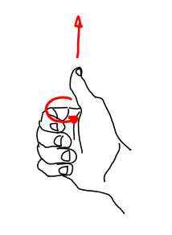

This rule for computing the magnitude and direction of a *torque vector* $\vec{T}$ is a description of what is called the *vector cross product.* In terms of the vector cross product, torque is written:

$$\vec{T} = \vec{r}\times \vec{F}$$

Many times, the method of computing the direction and magnitude of torque explained above, as the "distance times the perpendicular component of force," is the easiest way. However, in cases where oblique forces are applied at odd distances from a reference point, computing the torque using the *component-wise* cross product can be more useful.

## The vector cross product

Link to Original Context in: Reading_07

The vector cross product of two vectors $\vec{a}$ and $\vec{b}$ is shown as:

$$\vec{c} = \vec{a}\times\vec{b}$$

Any two vectors define a plane between them. In the cross product, the magnitude of $\vec{c}$ is given by the product of the magnitude $a$ with the component of $b$ which is *perpendicular* to the vector $\vec{a}$ in the plane defined between them. In the cross product, the vector $\vec{c}$ is always pointing into or out of the plane formed by $\vec{a}$ and $\vec{b}$.

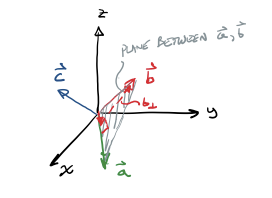

The magnitude $c$ of the vector $\vec{c}$ is given by:

$$c = a b_\perp$$

And the direction of $\vec{c}$ is given by the *right hand rule*, in which the fingers of the hand are pointed in the direction of $\vec{a}$ and then curled into the direction of $\vec{b}$. After doing this, the direction of $\vec{c}$ is revealed by the direction of the thumb.

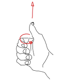

If the components of $\vec{a}$ and $\vec{b}$ are available, it is often easier to compute the magnitude and direction of $\vec{c}$ using the fact that the cross products of the unit vectors for the $x,y$ and $z$ directions for a standard, "right handed coordinate system," often denoted $\hat{i},\hat{j}$, and $\hat{k}$ respectively, are easy to compute.

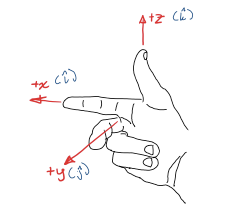

Because $\hat{i},\hat{j},\hat{k}$ are all perpendicular to one another, and because they all have a magnitude of 1, their individual cross products are easy to compute using the right-hand rule. Get out your right hand and try each of these yourself!

\begin{align} \hat{i}\times\hat{j} & = \hat{k} \\ \hat{j}\times\hat{k} & = \hat{i} \\ \hat{k}\times\hat{i} & = \hat{j} \\ \end{align}

Note that **the cross product is not commutative**, meaning that $\hat{j}\times\hat{i} \neq \hat{i}\times \hat{j}$. To prove this to ourselves, let's compute the reverses of the cross products above. Follow along!

\begin{align} \hat{j}\times\hat{i} & = -\hat{k} \\ \hat{k}\times\hat{j} & = -\hat{i} \\ \hat{i}\times\hat{k} & = -\hat{j} \\ \end{align}

The right-hand rule also tells us that any two components in the same direction have a cross product of 0, e.g. $\hat{i}\times \hat{i}=0$.

This may seem like a lot, but it makes computing cross products very quick and easy if components are available.

### Vector cross products using components: Example

Link to Original Context in: Reading_07

Let's say we wished to compute the torque on a tree trunk "growing" out of the ground that is produced by a force $\vec{F}$ acting at its tip, with respect to the ground. The position vector from the ground to the application of the force is $\vec{r}$.

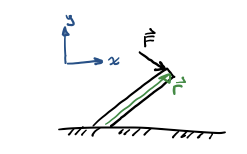

We know that $\vec{r} = 0.4\hat{i} + 1.2 \hat{j}$ meters, and that $\vec{F} = 100 \hat{i} - 200 \hat{j}$ Newtons. We could, of course, compute the magnitude of the torque using the formula $T = r\cdot F_\perp$, but we would need to compute the component of the force perpendicular to the position vector, which would require trigonometry. Instead, let's use the "standard" cross products for unit vectors above to speed things up. We can write:

$$\vec{T} = \vec{r}\times\vec{F} = (0.4\hat{i} + 1.2 \hat{j})\times(100 \hat{i} - 200 \hat{j})$$

Which, distributing the components using the "FOIL" (first, inside, outside, last) method, gives:

$$\vec{T} = (0.4\hat{i}\times 100 \hat{i}) + (0.4\hat{i} \times - 200 \hat{j}) + (1.2 \hat{j} \times 100 \hat{i}) + (1.2 \hat{j} \times - 200 \hat{j})$$

We can pull the magnitudes of each term out of the cross product to get:

$$\vec{T} = 0.4\cdot100(\hat{i}\times \hat{i}) + 0.4\cdot(- 200) (\hat{i} \times \hat{j}) + 1.2 \cdot 100 (\hat{j} \times \hat{i}) + 1.2 \cdot (- 200) ( \hat{j} \times \hat{j})$$

Then, using our unit-vector cross product relationships, we can compute the torque vector contribution of each term as:

$$\vec{T} = 0 -80\hat{k} -120\hat{k} + 0$$

Simplifying tells us that $\vec{T} = -200 \hat{k}N\cdot m$.

Using the right-hand rule, we can confirm that indeed the torque should be into the page, or in the $-\hat{k}$ direction.

## Newton's Second Law applied to angular momentum for a rigid body rotating about its center of mass in a plane

Link to Original Context in: Reading_07

Newton's second law, a statement about the conservation of momentum, applies to *angular* as well as linear momentum. For a rigid body moving in a plane, angular momentum is defined as:

$$\vec{H} = J \omega \hat{k}$$

Where $\omega$ is the magnitude of the rigid body's *angular velocity*, and $J$ is the *mass moment of inertia* of the rigid body. Think of the mass moment of inertia like a "mass for rotation." The larger this number is, the harder it is to accelerate an object in rotation.

Mass moment of inertia is a scalar quantity that is related to how mass is distributed in an object. A list of mass moments of inertia is available [here](https://en.wikipedia.org/wiki/List_of_moments_of_inertia), and the formal definition is given as:

$$J = \int r^2dm$$

Where "dm" represents an infinitesimal piece of mass that makes up the rigid body. It is rare that one needs to calculate a mass moment of inertia using this formula-- tables of mass moments of inertia for most common shapes are widely available, and most modern computer-aided design software can compute mass moments of inertia for parts you design. However, looking at the equation is helpful for understanding what moment of inertia *really is*. Imagine an object with all of its mass concentrated at a point. We could calculate that mass's *moment of inertia* with respect to some arbitrary axis as $J = mr^2$. By contrast, a wheel or a cube would have a different moment of inertia, since the mass of those objects is distributed in space.

Angular velocity, which has units of $\frac{rad}{s}$ in the SI system, has a *direction* either into or out of the plane of motion, according to the right-hand rule. with a standard coordinate system defined on a page as $x$ right and $y$ up, counterclockwise rotation is positive (out of the page), and clockwise rotation is negative (into the page). Newton's second law deals with the derivative of momentum. For a rotational system in a non-accelerating (also called "Newtonian") reference frame, we can write:

$$\sum \vec{T} =\frac{d\vec{H}}{dt}$$

Where **The angular momentum is computed about a rigid body's center of mass**. If moments (torques) are to be summed about an arbitrary point, this formula *does not, in general, apply*. There are special exceptions to this rule, but we will not treat them here.

As with a translational system, if the rotational inertia of a rigid body is constant, the right-hand side of the above equation can be written as $\frac{d\vec{H}}{dt} = J \dot{\vec{\omega}}$. In making this simplification, *and considering only motion in one plane,* we can write Newton's second law for a rigid body rotating about its center of mass as:

$$\sum \vec{T} = J \vec{\dot{\omega}}$$

You will often see this equation written as a scalar equation for objects that rotate only in one plane (such as a wheel functioning normally. If you imagine a wheel flying off of a car, you can see that it might have angular velocity about more than one axis of rotation). This scalar version of Newton's second law comes from the fact that if a body rotates only about one axis, its angular velocity (and thus, the torques that produce it) must all be going either into or out of the plane.

In summary, summing the torques about an object's center of mass to see how its *rotational velocity* changes over time is analagous to summing the *forces* applied to an object to see how its *velocity* will change over time.

## Idealized Rotational and Translational Dampers: Force and Torque

Idealized rotational and translational dampers are elements that have insignificant translational and rotational inertia, but that produce a force or torque that resists motion proportionally to the velocity difference between each part of the damper. "True" idealized dampers **do not exist**, because nothing is massless, and almost nothing has a purely linear relationship between force and velocity (or torque and angular velocity). However, *empirical observations* have led scientists and engineers to model many "real" system elements as if they were idealized dampers.

For example, rotational bearings and lubricated sliding contacts are often modeled as idealized dampers, as are translational "shock absorbers" such as those found on a car's suspension. Dampers are often indicated on a drawing using a shorthand sketch of their free body diagram:

Link to Original Context in: Reading_07

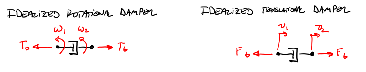

Because idealized rotational and translational dampers do not have significant mass, the torque or force (respectively) on each end of the damper must be equal and opposite.

The magnitude and of the torque on a rotational damper, as drawn above, is given by:

$$ T_b = b(\omega_1 - \omega_2)$$

Where $b$ is the damper's "damping coefficient." This coefficient is often experimentally determined, and its units are $\frac{N\cdot m \cdot s}{rad}$ in SI units so that multiplying the coefficient with an angular velocity in $\frac{rad}{s}$ yields a torque in $N\cdot m$. Note that using the right-hand rule, we can confirm that if $\omega_1$ is larger than $\omega_2$, the torque will point "outwards" from each end of the damper.

Similarly, for a translational damper, the equation for the force produced by the damper is given by:

$$ F_b = b(v_1-v_2)$$

The damping coefficient $b$ for a translational damper has units of $\frac{N\cdot s}{m}$ such that multiplying the coefficient by a velocity in $\frac{m}{s}$ produces a force in $N$.

## Energy

In one of his famous lectures, now available [online](https://www.feynmanlectures.caltech.edu/I_04.html), Nobel Prize-winning physicist Richard Feynman stated:

"It is important to realize that in physics today, we have no knowledge of what energy *is*."

What does he mean? Well, the human-made concept of "energy" has a [long and storied history](https://www.amazon.com/Warmth-Disperses-Time-Passes-Paperback/dp/0375753729/ref=sr_1_2?keywords=history+of+heat&qid=1582497717&sr=8-2). In essence, the concept was created to describe what scientists reliably **observe** when conducting experiments.

Let's proceed by example. If you rub your hands together, this involves "doing work." what is the result of this work? Your hands increase in temperature. If you place a ball on top of a hill, and let it roll down, it will have a predictable amount of velocity when it reaches the bottom of the hill. If I apply heat to a balloon full of air, it will expand. Energy is something "we" have come up with to link the relationships between **the work done on a system** and the **heat** a system exchanges with its environment. Specifically, based on repeated observation through the centuries, scientists accept the following about energy:

- Energy is neither created nor destroyed.

- For a system in which no mass crosses the boundary of the system definition, *Work* and *Heat* describe the only two ways we know of that a system can *exchange* energy with its surroundings. If the mass contained in a system's boundaries changes, then this change of mass can also result in a transport of energy.

To understand how to use these observations about "energy," we must first be specific about what we mean by "work" and "heat."

Link to Original Context in: Reading_09

## Work

Work, in the thermodynamic sense, is what occurs when a system exerts forces on its surroundings whose effects can be measured. Work can be produced by a pressure applied in order to change a system's volume, or by a force that physically moves a rigid body, or by an electric field that moves a charged particle. Work is usually expressed as a capital $W$, and has SI units of $Nm$ or "Joules."

Link to Original Context in: Reading_09

### Mechanical Work via a Force

Mechanical work is the product of a force and a distance. Specifically, work is the *integral* of force applied along a path.

$$W_{a\rightarrow b} = \int _\vec{a}^{\vec{b}} \vec{F}\cdot d\vec{S}$$

Consider a situation in which you are pushing a block of wood around on a table. By modeling the interaction between the block and the table using dry friction, where $F_f = \mu m g$, we can imagine that if the block of wood is moving at all times, the friction force applied to resist us pushing it around is constant, and always opposing motion. Imagine that you could choose to push the block along two possible paths, $S_1$ or $S_2$. The destination is the same, but $S_1$ is much longer.

Link to Original Context in: Reading_09

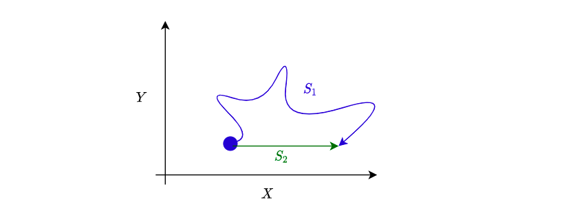

you might imagine that path $S_1$ would colloquially "take more work" to achieve, or "drain more of your energy." This is consistent with the formal definition of work!

## Mechanical Work via a Torque

In an analagous sense to the definition of mechanical work via a force, mechanical work is produced when a torque is applied to an object which moves through some angle. Formally, we can say:

$$W_{\theta_1 \rightarrow \theta_2} = \int_{\theta_1}^{\theta_2} T d\theta$$

Because torque has units of $Nm$, we find that in SI units, with radians as our measure of angle, mechanical work has the same units as it does for translation: $\frac{kgm^2}{s^2}$, which is equivalent to $Nm$ or Joules.

Link to Original Context in: Reading_09

## Heat

When people think of "heat," they usually think of temperature. Temperature is certainly a measure of the *intensity* of heat, but the way that we measure the *quantity* of heat is in terms of the energy it takes to raise a system's temperature. Because not all systems' temperatures can be changed with the same ease, temperature itself is not enough to describe the magnitude of "heat." For example, we could imagine that while a candle will burn our fingers almost immediately, it could not be expected to raise a large pot of water to its boiling point just as quickly.

In general, raising temperature is accomplished by either transferring heat from a hot object to a cold object, or by *doing work* that is converted to heat, such as when you rub your hands together to warm them up. In most of thermodynamics, the quantity of heat is denoted with the letter $Q$. Heat, in base SI units, does not have units of calories-- like work, and like measures of kinetic and potential energy, it has units of "Joules," or $Nm$.

Link to Original Context in: Reading_09

## Translational and Rotational Kinetic Energy in a Rigid Body

When a rigid body is moving, we say that it "stores" *translational kinetic energy,* which it can then exchange with its surroundings. The translational kinetic energy in a rigid body is:

$$E_k = \frac{1}{2}mv^2$$

Where $v$ is the scalar *magnitude* of its overall velocity. In SI units, this energy has units of Joules, or $\frac{kgm^2}{s^2}$.

When a rigid body rotates, it stores *rotational kinetic energy*. Rotational kinetic energy, which also has units of Joules, is given by:

$$E_k = \frac{1}{2}J\Omega^2$$

Where $\Omega$ is the magnitude of the angular velocity of the object (in $\frac{rad}{s}$ for SI units) about its center of mass, and $J$ is the mass moment of inertia of the object about its center of mass (in $kgm^2$ in SI units).

Link to Original Context in: Reading_09

## The First Law of Thermodynamics: The conservation of Energy

The first law of thermodynamics, also called "the conservation of energy," states that energy is never created nor destroyed... merely exchanged between a system and its surroundings. It is this law that tells us that [perpetual motion machines cannot exist](https://en.wikipedia.org/wiki/Perpetual_motion), as they produce work without the input of energy from outside of the system.

Link to Original Context in: Reading_09

Because energy can only be transferred through either work or heat in a closed system, we can draw the relationship between a system of interest and its surroundings using the following diagram:

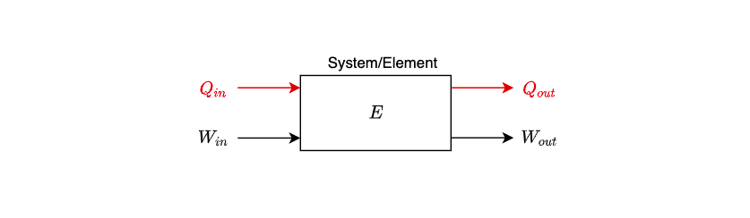

You may notice that this looks like our "system scope" diagram, but it deals with energy only. We represent internal (stored) energy, work done on the system from the external environment, work done *by* the system on its external environment, heat applied *to* the system from the external environment, and heat applied *by* the system to its external environment explicitly. Formally, we can write the change in energy *stored* inside the system from some "initial state" 1 to some "later state" 2 using the following equation, which is a statement of the first law:

$$ E_2 - E_1 = \Delta E = \delta W_{in} - \delta W_{out} + \delta Q_{in} - \delta Q_{out}$$

This says that if the balance of energy transfer between our system and its environment can be interpreted as the environment "doing work" on or "transferring heat to" our system of interest, it will increase the amount of energy stored *inside* our system if our system did not do work on its environment, or exchange heat with its environment.

In the opposite scenario, if balance of energy transfer between our system and its environment can be interpreted as our system "doing work" on its surroundings or "transmitting heat to" its surroundings, we say that the amount of energy stored in our system goes down.

If we consider that bringing our system from "energy state 1" to "energy state 2" requires time (which it always will), we can say that the *rate of change in energy in our system* can be written as:

$$ \frac{E_2 - E_1}{t_2-t_1} = \frac{\Delta E }{\delta t}= \frac{\delta W_{in}}{\delta t} - \frac{\delta W_{out}}{\delta t} + \frac{\delta Q_{in}}{\delta t} - \frac{\delta Q_{out}}{\delta t}$$

Shrinking $\delta t$ to an infinitesimal value leads to the derivative of our original first law equation, which is a totally equivalent statement about the conservation of energy:

$$ \dot{E} = \dot{W}_{in} - \dot{W}_{out} + \dot{Q}_{in} - \dot{Q}_{out}$$

The derivative of energy (and thus, the derivatives of power and heat) have units of $\frac{J}{s} = \frac{kgm^2}{s^3}$, which are commonly called "Watts" in SI units. There is also a very special name for the time-derivative of energy, and it is **power**.

## Power

Power is the time derivative of energy. In SI units, power has units of "Watts," or Joules per second. Power can take many forms, including thermal, mechanical, and electrical.

Link to Original Context in: Reading_09

## Gravitational Potential Energy

Gravitational "potential energy" is defined by how much work gravity "could do" on an object. Consider the following drawing of a ball at the "top" and at the "bottom" of a hill, at two different energy states, 1 and 2.

Link to Original Context in: Reading_10

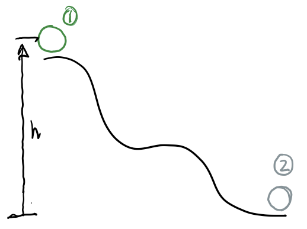

We know from Newton's second law that gravity will "pull" the ball down the slope. In doing so, gravity "does work" by applying its force on the ball over the distance its center of gravity moves. We find that the amount of work gravity can do on the ball is simply a function of the difference in height between where the ball started and our "zero reference point," or the bottom of the hill. Formally, gravitational potential energy can be written:

$$E_g = mgh$$

The height "h" is always a choice. It is possible to define it, for instance, from the center of the earth, but usually it is defined relative to a convenient plane of "zero" gravitational potential energy. "Zero" is in quotes there because it's not really zero... it's really just the place, in our system definition, where gravity can no longer do work on our system.

## Pressure in a fluid

Link to Original Context in: Reading_10

Because fluids conform to their surroundings, the idea of a force applied at a "point" is less useful for fluids than it is for solid bodies. When we talk about fluids, we usually talk about pressure. Pressure is defined as *normal force* per unit area. This applies to solid bodies as well, but pressure is a key concept in the study of how fluids move (or don't). If $F$ is force normal to the surface of an arbitrary "fluid element" with area $A$, the pressure applied to that surface is defined as:

$$P = \frac{F}{A}$$

In SI units, pressure has units of $\frac{N}{m^2}$, which is also called a "Pascal," abbreviated $Pa$.

Pressure in a fluid is usually measured as a difference from *atmospheric* pressure. This is called "gauge pressure." Gauge pressure is different from "absolute pressure," which is measured relative to a perfect vacuum.

## Hydrostatic Pressure

If you have ever been in a pool, you probably know that when you dive deep, you feel increased pressure on your eardrums. Why is this? Well, if we were to look at a rectangular prismatic "chunk" of fluid, also called a "fluid element" with a width $\Delta x$, a height $\Delta z$, and a thickness into the page of $\Delta y$, we could draw its free body diagram as follows:

Link to Original Context in: Reading_10

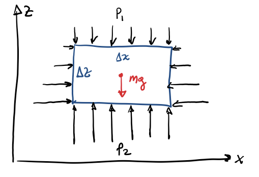

The gravitational force on this fluid element is $mg$, where mass $m$ can be calculated from the volume of the chunk multiplied by its density $\rho$. This means:

$$ mg = \rho V g$$

Where $V = \Delta x \Delta y \Delta z$. If we imagine that the element is in equillibrium, we could actually write Newton's second law for it in the z-direction.

$$\sum F_z = P_2 \Delta x \Delta y - P_1 \Delta x \Delta y - \rho \Delta x \Delta y \Delta z g = 0$$

After cancaling $\Delta x \Delta y$ from all terms, we can see that:

$$P_2 - P_1 = \rho g \Delta z$$

This means that the pressure in a fluid increases linearly with depth, which leads to the standard equation for hydrostatic pressure expressed as a *gauge pressure*, meaning $P_{atm}=0$:

$$P_2-P_1 = P - P_{atm} = P = \rho g h$$

## Work done via fluid flow

Like moving a solid body, moving a fluid takes work. Our definition of mechanical work was:

$$W = \int \vec{F} \cdot d\vec{s}$$

In a fluid, pressure is defined as force normal to a fluid surface per unit area. If a fluid flows through a thin "slice" of pipe, perhaps with thickness $dx$ and cross sectional area $A$, we can say that the work done in pushing fluid through this section of pipe could be written:

$$W = P A dx = P V$$

Link to Original Context in: Reading_10

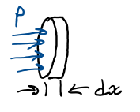

If we take the time derivative of this expression, we can get an expression for the *power* that is expended when moving a fluid at a certain velocity using a certain pressure.

$$\dot{W} = P\dot{V}$$

## Electrical Work

Link to Original Context in: Reading_11

$$\require{cancel}$$

Electrical work is done by moving charged particles. Electrical work *is* mechanical work, so its definition is fundamentally the same as the definition for work used in a mechanical system: $$W = \int \vec{F}\cdot d\vec{s}$$

Charged particles can be moved by an electric field that exerts force on those particles. While it is possible to compute work exerted on individual particles due to an electric field, the turn of the 19th century saw the first definitions of a quantity that we now call "Voltage." Today, we recognize a Voltage, or "electric potential," as something that is capable of doing work on a particular quantity of charged particles. Our definition of work, which is consistent with a few others that can be derived, is:

$$V = \frac{W}{Q_e}$$

Where $Q_e$ is electric charge (not to be confused with a quantity of heat $Q$.)

In SI units, multiplying a 1 Volt by 1 Coulomb of charge yields 1 Joule of work done.

This definition was inspired by early work with electrochemical sources of energy, which evolved into the modern battery. Batteries store chemical energy, and when a path for electrical charge exists between a battery's positive and negative terminals, this energy is transferred to whatever system the battery is intended to do work on. Batteries generally have a relatively constant *voltage* while their level of stored charge is near its maximum, as long as the power requiremments of the system are low.

## Electrical Power

Link to Original Context in: Reading_11

As with power in fluid and mechanical systems, electrical power is the time derivative of energy transfer. Given a particular voltage (not to be confused with volume) between two points in an electrical system, this time derivative can be computed for electrical work as:

$$\dot{W} = V \frac{dQ_e}{dt}$$

The time derivative of charge moving through an electrical system or element has a special name: Current, which we denote with a lowercase $i$.

$$\frac{dQ_e}{dt} = i$$

In SI units, current has units of Amperes, or $A$. 1 Ampere is, by definition, equivalent to 1 Coulomb per second of charge. This allows us to write electrical power as:

$$\dot{W} = Vi$$

### Similarity between capacitors and water tanks

$$\dot{E} = \rho g h A \dot{h} = P_t \dot{\mathcal{V}}$$

The pressures in the tank equation are like the voltages in the capacitor, while volumetric flow rate into the tank is analagous to current into the capacitor.

Note that we could write $\dot{P}_{t} = \rho g \dot{h}$, which changes the first law equation to:

$$\dot{E} = h A \dot{P}_t = P_t \dot{\mathcal{V}}$$

In fact, many engineers define that "capacitance" of a water tank as:

$$C_{tank} = \frac{A}{\rho g} = \frac{A h}{\rho g h} = \frac{\mathcal{V}}{P}$$

Compare this with the definition of capacitance in a capacitor, which is $C = \frac{Q_e}{V}$. Again, see the similarities between pressure and voltage (and charge and volume) here.

With this substitution, we can rearrange the first law of thermodynamics for the tank as:

$$\dot{E} = C \dot{P}_t P_t = P_t \dot{\mathcal{V}}$$

Link to Original Context in: Reading_11

### Ohm's Law

Link to Original Context in: Reading_11

Today, we write Ohm's law as:

$$V_1 - V_2 = V_{12} iR$$

## Nodes

In system dynamics, a "node" is a fictitious element in your system through which power is transferred without energy storage or "losses" (energy transfer to outside the system boundary). In the case of an electrical, fluid, or mechanical system, we could say that a "node" represents a fictitious place where no heat transfer occurs from the system to its environment and no energy is stored.

Link to Original Context in: Reading_13

### Nodes in electrical systems

The easiest place to look for an almost literal representation of a node is in an electrical schematic, where two or more "ideal wires" (wires with negligible resistance) join together at a point. See the example below for a node joining three wires.

Link to Original Context in: Reading_13

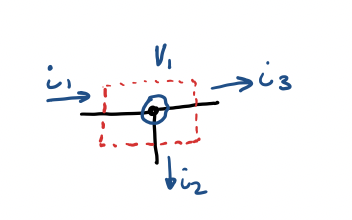

With our assumptions of no heat transfer and no energy storage in place, Writing the First Law of Thermodynamics for the electrical node yields:

$$\require{cancel}$$$$\cancel{\dot{E}} = \dot{W}_{in} - \dot{W}_{out} + \cancel{\dot{Q}}_{in} - \cancel{\dot{Q}}_{out}$$

Rewriting, we see that $\dot{W}_{in} = \dot{W}_{out}$. If our "node" represents an infinitesimal junction between wires with negligible resistance, the voltage that exists at each "end" of the node cannot be different. Therefore, we can make the assumption that at an electrical node, there can be only one voltage, $V_1$.

**Then, Adopting the sign convention that currents flowing out of the node correspond with work flowing 'out' of the node**, we can then write our first law of thermodynamics as:

$$ V_1 i_1 = V_1i_2 + V_1 i_3$$

Because we have only one voltage at the node, it is common to cancel it and write:

$$ i_1 = i_2 + i_3$$

Which is simply a re-statement of the first law of thermodynamics **under specific conditions and assumptions**. Because there is only one voltage, the currents must "split" in a way that conserves energy. Here, the conservation of energy boils down to a conservation of charged particles *that can neither be created nor destroyed* via the law of conservation of mass. The equation above, in electrical systems, is often called "Kirchoff's Current Law" or "KCL."

### Nodes in Fluid Systems

Link to Original Context in: Reading_13

$$\cancel{\dot{E}} = \dot{W}_{in} - \dot{W}_{out} + \cancel{\dot{Q}}_{in} - \cancel{\dot{Q}}_{out}$$

Rewriting, we see that $\dot{W}_{in} = \dot{W}_{out}$. If our "node" represents an infinitesimal junction between pipes, and **if** this junction has negligible resistance, the pressure that exists at each "end" of the node cannot be different. Therefore, we can make the assumption that at a fluid node, there can be only one pressure, $P_1$. Then, adopting the same sign convention as we did for the electrical system with inflows and outflows, we can write the first law of thermodynamics as:

$$P_1(\dot{\mathcal{V}}_1 + \dot{\mathcal{V}}_3) = P_1 \mathcal{\dot{V}}_2$$

Cancelling the extra power of $P_1$, the first law reduces to a simple conservation of flow rate equation, or:

$$\dot{\mathcal{V}}_1 + \dot{\mathcal{V}}_3 = \mathcal{\dot{V}}_2$$

### Nodes in Mechanical Systems

Link to Original Context in: Reading_13

The concept of a node for a mechanical system is a little trickier, but only because we have *two sets* of tools with which to analyze mechanical systems: Newton's laws and the first law of thermodynamics. But the concept of a node is still the same: it is a point in our system at which we could say that no energy is transferred outside of the system boundary (no "losses") and no energy is stored. Consider the following system, in which a large mass, connected to ground through a damper, is connected to a second mass through a damper.

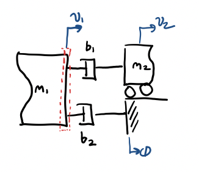

Now, one approach to studying this problem might be to simply draw energetic diagrams for the two dampers and the mass separately. Doing so using the standard assumptions for "idealized" masses and dampers might look like this:

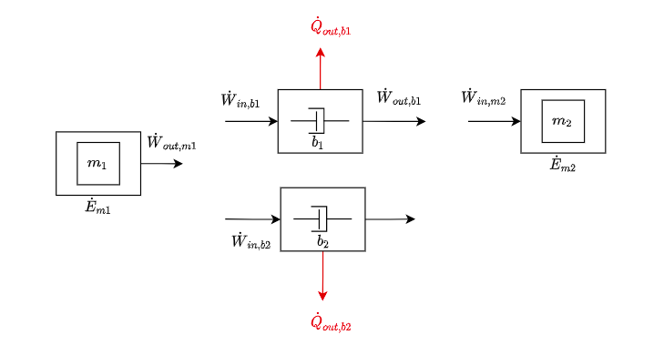

But how does one know how the power $\dot{W}_{out}$ from $m_1$ "splits" to yield the input powers $\dot{W}_{in}$ for $b_1$ and $b_2$? Well, you might say that $\dot{W}_{out,m1} = \dot{W}_{in,b1}+\dot{W}_{in,b2}$ by inspection, but how do we *know* this is the case? Is there a more formal statement we can make?

Consider the dotted red box in the first picture. If we consider a tiny "slice" of the system that represents the physical connection between the mass and the two dampers, we could say that this slice has both negligible mass and negligible transfer of energy through the system boundary as heat. We could draw this in as another energetic element in our system as follows:

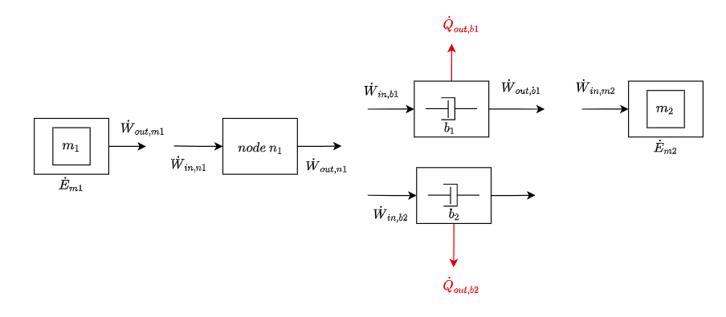

Zooming in on this new element and looking at the power (forces and velocities) "flowing" in and out of it, we could draw:

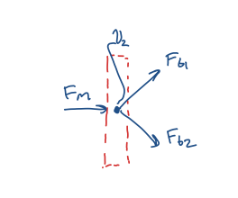

As before, we could use these assumptions to write a simplified version of the first law of thermodynamics in derivative (power) form for this element.

$$\cancel{\dot{E}} = \dot{W}_{in} - \dot{W}_{out} + \cancel{\dot{Q}}_{in} - \cancel{\dot{Q}}_{out}$$

We can then re-write this as $\dot{W}_{in} = \dot{W}_{out}$ for this fictitious element, which we'll call a node. To write the power terms in the first law more explicitly as the product of force and velocity, we could say that the "effective" or "net" force from the mass, which we'll call $F_m$, does work *on* the node, while the forces acting on the dampers are work "out" from the node. We can also say that because the node is a rigid element (it is the connection between the mass and its two dampers, in this example), there is only one velocity at the node! In this case, that velocity is $v_1$, or the velocity of $m_1$. Then, we could write the first law of thermodynamics for this node as:

$$F_m v_1 = F_{b1}v_1 + F_{b2} v_1$$

Cancelling the extra power of $v_1$ yields:

$$F_m = F_{b1} + F_{b2}$$

This, incidentally is a reduced statement of the first law of thermodynamics in derivative (power) form if we do not cancel $v_1$. If we do cancel that term, the equation is a restatement of Newton's 2nd law, where for the node, $\sum F = \cancel{m_{node}}\dot{v}_1 = 0$ since the node's mass is negligible. Analyzing this system with Newton's laws would show us that $F_m$ in the diagram above represents the "total force" of the two dampers on the mass-- in this representation, with the node "in between" the mass and the two dampers, we are simply saying that the node is the only "thing" exerting force on the mass (sort of like a middleman).

## The principle of Continuity

The principle of continuity is a re-statement of the first law of thermodynamics with specific assumptions. For many types of systems, the assumptions boil the first law of thermodynamics down to a simple statement about conservation of mass. In these cases, the principle of continuity states:

"flows into a node must balance with flows out of a node,"

Where the definition of "flows" depends on the type of system at hand. For electrical systems, the principle of continuity at a node boils down to a "conservation of current," or Kirchoff's Current Law:

$$\sum i _{node} = 0$$

With currents into a node considered positive, and currents out of a node considered negative.

For a mechanical system, Force is the quantity that "flows through" elements via Newton's 3rd law (making an imaginary cut anywhere along a rigid body and drawing a free body diagram will confirm this). Thus, a "node" in a mechanical system is an imaginary element with "no" mass. Writing the first law of thermodynamics for a node in a mechanical system, and canceling that its (single) velocty from the first law equation, one obtains:

$$\sum {F}_{node} = 0$$

For a fluid system (incompressible), a "node" might represent an infinitesimal junction between two pipes or valves, or a junction between a valve and a tank. Writing the first law of thermodynamics for this "infinitely thin" element in which only one pressure exists (and can thus be canceled), one obtains:

$$\sum \dot{\mathcal{V}}_{node} = 0$$

With volumetric flows into the node being considered positive, and flows out of the node negative.

Link to Original Context in: Reading_13

## Generalized Fluid Capacitors

While a simple tank storing energy in gravitational potential is one example of a fluid "capacitor," or ideal fluid potential energy storage element, working against gravitational potential is not the only way a vessel full of fluid can store energy. In many cases, a fluid storage vessel can store potential energy by "stretching" or increasing its volume elastically as it is filled.

In fact, the concept of the "fluid capacitor" can be applied to any fluid element that can be reasonably modeled as storing fluid potential energy without heat transfer, which means there is no significant resistance at the inlet to the vessel. Consider the following drawing, which represents a "balloon-like" fluid capacitor that stretches to store fluid as flow work is done on the element to result in an influx of fluid, $\dot{\mathcal{V}}_c$.

Link to Original Context in: Reading_13

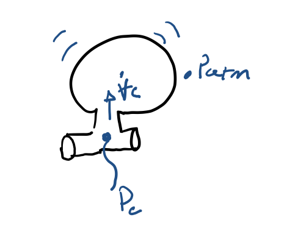

Writing the first law of thermodynamics for this element, assuming no heat transfer at the inlet, yields:

$$\dot{E} = \dot{W}_{in} - \dot{W}_{out} + \cancel{\dot{Q}}_{in} - \cancel{\dot{Q}}_{out}$$

This means that the energy stored in the capacitor will go up if the net work $\dot{W}_{net} = \dot{W}_{in}-\dot{W}_{out}$ is positive. This work is flow work, where, defined using gauge pressure, we see:

$$\dot{W}_{net} = (P_c - \cancel{P_{atm}})\dot{\mathcal{V}} = P_c \dot{\mathcal{V}}_c$$

Now, it is true that knowing just how much work needs to be done to "stretch" the balloon out and fill it with more fluid can be tricky. To actually stretch the vessel, work must be done to increase the pressure inside the vessel with respect to atmospheric pressure, and this usually involves complex calculations how how stiff the vessel's material is.

Many times, a physics-based calculation of this work is intractible. Therefore, the effective "compliance" of a fluid capacitor is often studied empirically, and is characterized by defining a "fluid capacitance" for the vessel. **Defining** the capacitance of the element as $C\equiv \frac{ \mathcal{V}}{ P}$ allows us to develop an equation that is very similar to that of the electrical capacitor, as seen in Reading 11. Specifically, we can define the capacitor's stored energy by saying that "all of the work done on the element is stored energy," according to the first law equation we wrote above. Formally, that looks like this:

$$E_{stored} = W_{net} = \int_0^{\mathcal{V}_c} P_c(\mathcal{V}_c) d\mathcal{V}_c = \int_0^{\mathcal{V}_c} \frac{\mathcal{V}_c}{C} d\mathcal{V}_c = \frac{\mathcal{V}_c^2}{2C} = \frac{ P^2_c C^2}{2C} = \frac{1}{2}CP_c^2$$

Using this definition, we can write the first law of thermodynamics for a generalized fluid capacitor as:

$$\dot{E} = \dot{W}_{net} = CP_c \dot{P}_c = P_c \dot{\mathcal{V}}_c$$